# Test different clustering methods

## Package cluster

### `clara()`

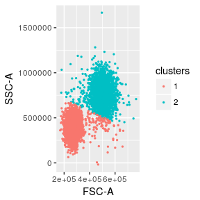

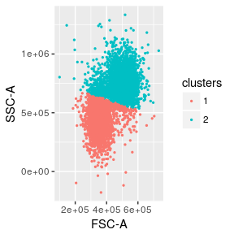

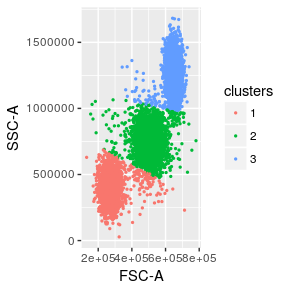

```r
library(cluster)

test_cluster_clara <- function(.cur_test_set){
  .data <- .cur_test_set$.data
  .n_clusters <- .cur_test_set$.n_clusters

  clust_res <- clara(.data[, c(1, 2)], k = .n_clusters, samples = 500, pamLike = TRUE)

  .data$clusters <- as.character(clust_res$clustering)

  plot_facs(.data, .beads = "clusters")
}

test_data %>% map(test_cluster_clara) %>% walk(print)
```

### `fanny()`

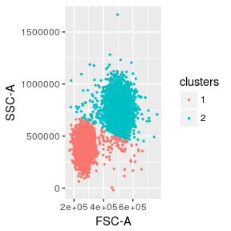

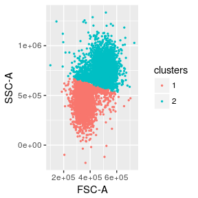

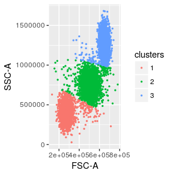

```r
library(cluster)

test_cluster_fanny <- function(.cur_test_set){
  .data <- .cur_test_set$.data
  .n_clusters <- .cur_test_set$.n_clusters

  clust_res <- fanny(.data[, c(1, 2)], k = .n_clusters)

  .data$clusters <- as.character(clust_res$clustering)

  plot_facs(.data, .beads = "clusters")
}

test_data %>% map(test_cluster_fanny) %>% walk(print)
```

### `pam()`

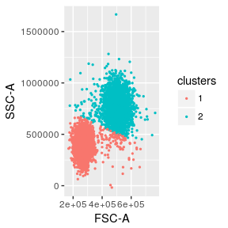

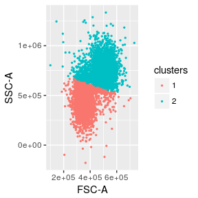

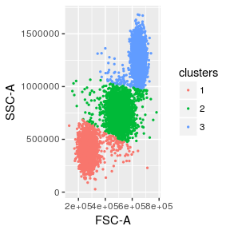

```r
library(cluster)

test_cluster_pam <- function(.cur_test_set){
  .data <- .cur_test_set$.data
  .n_clusters <- .cur_test_set$.n_clusters

  clust_res <- pam(.data[, c(1, 2)], k = .n_clusters)

  .data$clusters <- as.character(clust_res$clustering)

  plot_facs(.data, .beads = "clusters")
}

test_data %>% map(test_cluster_pam) %>% walk(print)
```

In general, the methods of the **cluster** package are not usefull for the same reason that the kmeans clustering is not usefull.

## Fused lasso

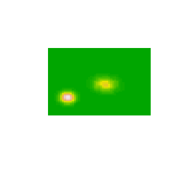

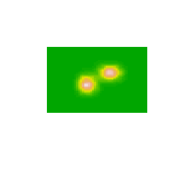

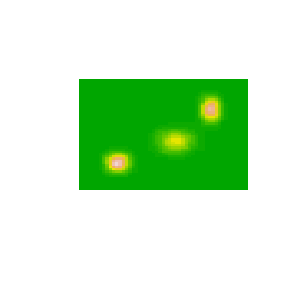

```r
library(genlasso)
library(KernSmooth)

.cur_test_set <- test_data[[3]]
test_lasso <- function(.cur_test_set){
  .data <- .cur_test_set$.data
  .n_clusters <- .cur_test_set$.n_clusters

  .data_matrix <- .data %>%
    dplyr::select(`FSC-A`, `SSC-A`) %>%
    as.matrix()

  binwidth_x <- dpik(.data_matrix[, 1])
  binwidth_y <- dpik(.data_matrix[, 2])

  y <- .data_matrix %>% KernSmooth::bkde2D(bandwidth = c(binwidth_x, binwidth_y))
  y <- y$fhat

  # I don't know if approx speed up things a bit
  out <- fusedlasso2d(y,approx = TRUE)

  # This works at least for the examples
  co <- coef(out, nlam = 5)

  cols <- terrain.colors(30)
  zlim <- range(c(co$beta,y))

  image(matrix(co$beta[,5],nrow=nrow(y)),col=cols,zlim=zlim,axes=FALSE)
}

test_data %>% walk(test_lasso)
```

Fused lasso can be applied to the problem, but suffers two major drawbacks: It is painstakingly slow and there is little room to automate group selection. It is bacically an expensive way to reduce/remove noise in the data.